# Horror Films

Amit Levinson

10/23/2019

Today’s TidyTuesday analysis is on horror films rated on IMDb.com. Let’s start by loading the packages we’ll need and load our file:

```r
library(tidyverse)
library(stringr)
library(ggbeeswarm)
library(ggrepel)
library(extrafont)
horror_movies <- readr::read_csv("https://raw.githubusercontent.com/rfordatascience/tidytuesday/master/data/2019/2019-10-22/horror_movies.csv")
```

Great. let’s have a look at our data

```r
glimpse(horror_movies)
```

```
## Observations: 3,328
## Variables: 12
## $ title             <chr> "Gut (2012)", "The Haunting of Mia Moss (201...
## $ genres            <chr> "Drama| Horror| Thriller", "Horror", "Horror...
## $ release_date      <chr> "26-Oct-12", "13-Jan-17", "21-Oct-17", "23-A...
## $ release_country   <chr> "USA", "USA", "Canada", "USA", "USA", "UK", ...
## $ movie_rating      <chr> NA, NA, NA, "NOT RATED", NA, NA, "NOT RATED"...
## $ review_rating     <dbl> 3.9, NA, NA, 3.7, 5.8, NA, 5.1, 6.5, 4.6, 5....
## $ movie_run_time    <chr> "91 min", NA, NA, "82 min", "80 min", "93 mi...
## $ plot              <chr> "Directed by Elias. With Jason Vail, Nichola...
## $ cast              <chr> "Jason Vail|Nicholas Wilder|Sarah Schoofs|Ki...
## $ language          <chr> "English", "English", "English", "English", ...
## $ filming_locations <chr> "New York, USA", NA, "Sudbury, Ontario, Cana...
## $ budget            <chr> NA, "$30,000", NA, NA, NA, "$3,400,000", NA,...
```

So I want to look at the rating of the movie in accordance to its length. Do longer horror movies rate higher than shorter ones?  
The `movie_run_time` is structured as a character and not a numeric value. it contains both our minutes value and a string character of ‘min’. we want to eliminate the ‘min’ part, rendering it suitable for a numeric value:

```r
rating_length <- horror_movies %>%
  mutate(movie_length = as.numeric(str_replace(movie_run_time,"min", ""))) %>%
  filter(!is.na(movie_length) & !is.na(review_rating))
```

`stringr::str_replace` is a great function for removing strings and characters. after removing it, i wanted to make sure it’s rendered numeric so I used `as.numeric`.

Let’s look at how the ratings distribute across movie length:

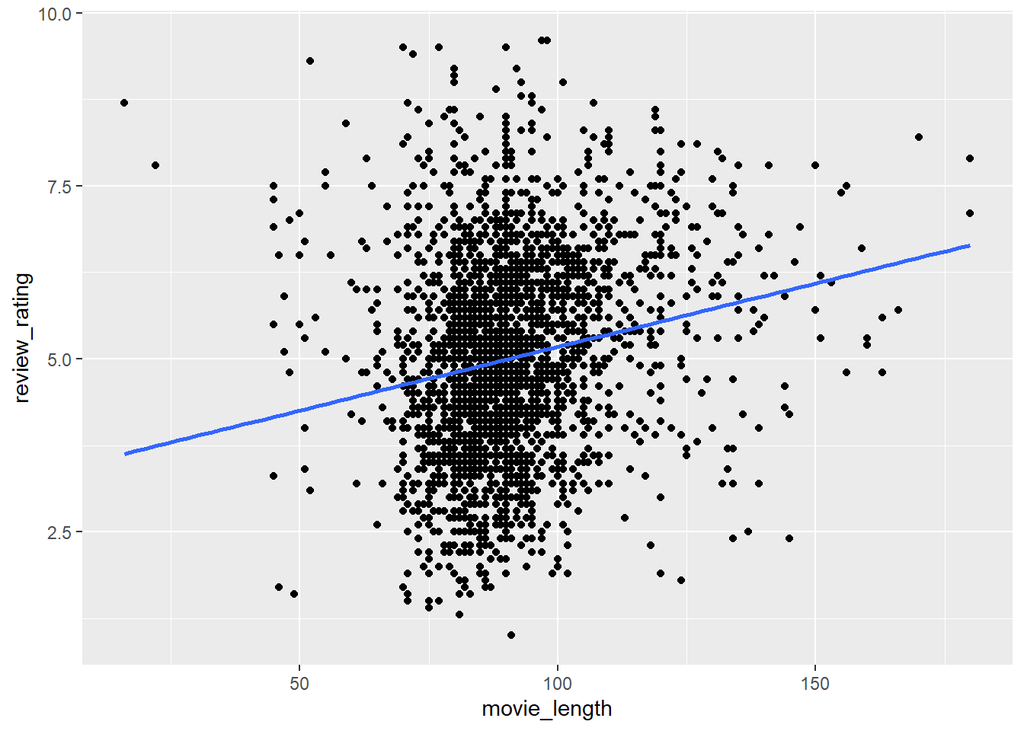

```r
rating_length %>%
  ggplot(aes(x = movie_length, y = review_rating))+
  geom_point()+
  geom_smooth(method = "lm", se = FALSE)
```

OK, so we see some sort of a pattern, but it;s not that evident. it might be worth dividing the data frame into groups of duraiton intervals and looking at differences across groups, since in longer movies we’d expect a higher rating.  
Let’s try dividing it into three groups:

```r
rating_length <- rating_length %>%
  #creating length categories of the movies
  mutate(length_cat =
         ifelse(movie_length <80, "Under 1:20",
         ifelse(movie_length >=80 & movie_length < 100, "1:20-1:40", "1:40+")),
         #Now let's reorder the factor level
         length_cat = factor(length_cat, levels = c("Under 1:20","1:20-1:40", "1:40+"))) %>%
    select(title, review_rating, movie_length, length_cat)
```

and now for the plot:

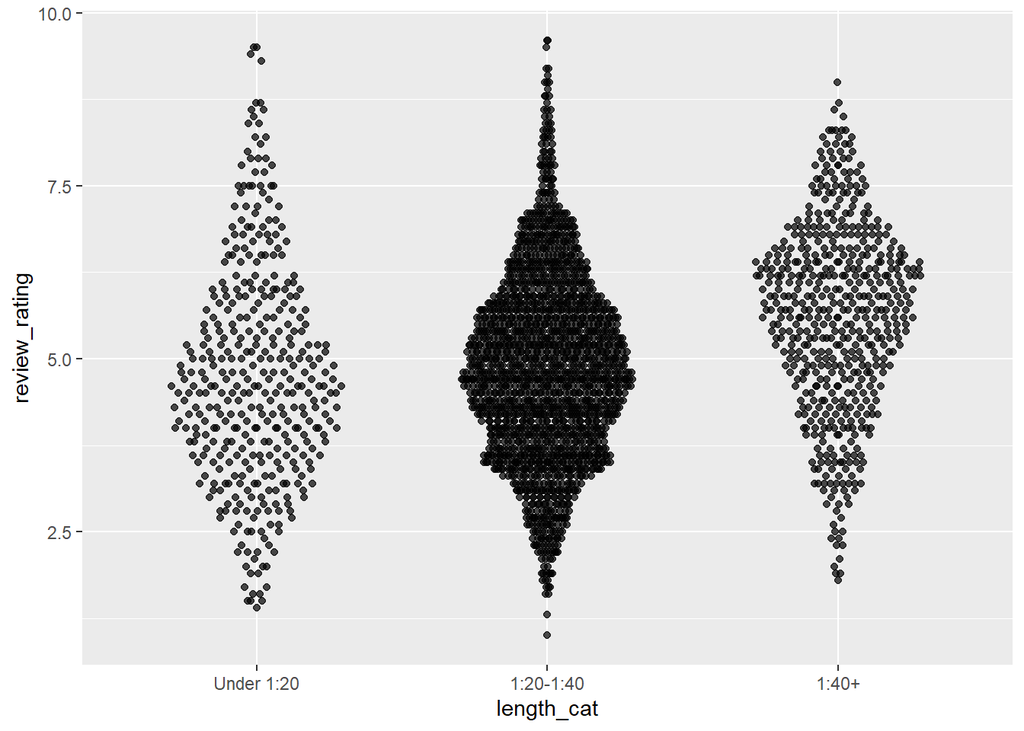

```r
  ggplot(rating_length, aes(y = review_rating, x = length_cat))+
  #Creating a beeswarm plot
  geom_quasirandom(alpha = 0.7, width = 0.3)
```

Hmm, so this shows a little more of a pattern, but not much. I used the `beeswarm package` that can efficiently shows the scatter on a factorial level. I encountered this at [Christian Burkhart blog post](https://ggplot2tutor.com/powerlifting/squats/) analyzing the #TidTuesday data set on powerlifting.  
Turning to the plot, the average seems kind of equal, plus the middle group (1:20-1:40) has much more values, so it’s not necessarily definite that the correlation exists. However, I like the way the top ranked movies distant themsevls from the rest of the distribution, plus there does seem like a little difference acorss groups.

let’s try labeling those top 3 for each group, plus drawing the average point for each distribution: